# EEMB146 Lab7 Exercise

Written by Samantha Sambado and Tatum Katz

2023-12-30

## Exercise 7 – Correlation & Linear Regression

# Learning Objectives

- Know how to interpret a correlation coefficient ** value**
  - -1 = perfect negative correlation
  - 0 = no correlation
  - 1 = perfect positive correlation
- Know the **assumptions of Pearson’s** correlation co-efficient
  - X & Y have a bivariate normal distribution
- Know the **difference between a Pearson’s vs Spearman’s** correlation test
  - type of test: Pearson’s (parametric) vs Spearman’s (non-parametric)
  - test statistics: Pearson (t) vs Spearman’s (S)
  - the interpretation of Spearman’s is a rank value
- Know **assumptions of a Linear Regression Model**
  - random sample
  - $Y_i$’s are independent
  - residuals are normally distributed with equal variances

# Background

## 1. Correlation

### 1.1 Correlation (in general)

Correlation tells us (1) whether **two numeric variables** are linearly associated with each other and (2) how they are associated (positively, negatively, or neither). For example, I may be interested in whether large bodied animals have larger brains: in other words, are body mass (**X**) and brain size (**Y**) correlated? To answer this question, I need to use something called **Pearson’s correlation coefficient**, which is written as *r*. The *r* coefficient has the following properties:

1. It has a **value** between
   - -1 (perfect negative correlation)
   - 1 (perfect positive correlation)
   - 0 indicates no correlation.
2. It is defined as by the **equation**:
   $$r = \frac{ \Sigma(X -
   \bar{X})(Y-\bar{Y})}{\sqrt{\Sigma(X-\bar{X})^2}\sqrt{\Sigma(Y-\bar{Y})^2}}$$
   - Notice that if we were interested in the correlation of X with itself (body mass with body mass) equation 1 would be 1 (aka a perfect positive correlation).
3. **r** is only looking for a **linear** correlation between variables. It will not identify non-linear patterns.

### 1.2 Pearson’s correlation coefficient (parametric)

While **r** by itself can be useful, we often want to determine whether the correlation between two variables is significant. To do this wee need to make the following **assumptions about X and Y**:

1. **X** and **Y** follow a **bivariate normal distribution**. This is actually difficult to test directly, but we can look at the following features of our correlation and if they hold we can assume bivariate normality:
   - Is the relationship between **X** and **Y** linear?
   - Does the cloud of points have an **elliptical shape**?
   - Are **X** and **Y** both normal?

Again, this does not guarantee bivariate normality, but it is good enough for our purposes. If these **assumptions are not met, try transforming the data**!

If the assumptions are met, then we can run a Pearson’s correlation to test the hypotheses that there is a significant correlation between two variables **X** and **Y** by asking whether $\rho$ (the true value of **r**) is equal to zero or not:
$$H_0 : \rho = 0 \\ H_A: \rho \neq 0$$

We can use a standard t-test to do this:
$$t = \frac{r}{SE_r}$$

where $SE_r$ is:
$$SE_r = \sqrt{\frac{1-r^2}{n-2}}$$

and **n** is the number of (**X**,**Y**) pairs.

You will learn more about conducting a Pearson’s correlation test in the following R exercises.

### 1.3 Spearman’s rank correlation (non-parametric)

If the assumptions of the parametric correlation are not met you can use a non-parametric alternative called **Spearman’s rank correlation**. Like all of the non-parametric tests that we have seen in this class, Spearman’s rank correlation looks at an association between the rank of the two variables. There are two assumptions of this test:

1. The observations are random samples (surprise, surprise..)
2. The relationship between **X** and **Y** is monotonic

You will learn more about conducting a Spearman’s rank correlation test in the following R exercises.

## 2. Linear Regression Model

*you will see the linear regression model referred to as linear model (aka lm)*

### 2.1 Model Terminology

Before we get started, we need to review a little terminology:

- **Y**: response variable
- **X**: predictor (explanatory) variable

Linear regression is used when you want to:

- Investigate how a **Y** depends on **X**
- Predict **Y** using **X**

For example, if you were interested in determining whether a baby’s age (**X**) was a significant predictor of a baby’s ear length (**Y**), you would collect a bunch of (**X**,**Y**) pairs and build a regression model. From this model you could predict the expected ear length of a baby who was, say, 18 months old. What would this model look like? What are the assumptions of the model? Proceed to the next section to find out!

### 2.2 Model Hypotheses

While we can test many hypotheses with a linear regression model, the most common hypotheses that we will test is whether **X** is a significant predictor of **Y**. In other words, is the **slope** of our regression line **different from 0**? This is phrased as
$$H_0: \beta_1
= 0 \\ H_A: \beta_1 \neq 0$$
.

### 2.3 Model Structure

Your book gives the linear regression model as
$$Y = a + bX$$
.

but you more often see it written as
$$Y_i
= \beta_0 + \beta_1X_i+\epsilon_i$$
.

where $\beta_0$ is the y-intercept, $\beta_1$ is the slope of the line, and $\epsilon_i$ is a random variable that is normally distributed with a mean of 0 and variance $\sigma^2$. Written in terms of our baby example it would look something like
$$(ear length)_i = \beta_0 + \beta_1(baby age)_i +
\epsilon_i$$
.

All this is saying that the **response variable** (baby ear length) can be **predicted** from our **explanatory variable** (baby age). The $\epsilon_i$ is telling us that each observation has a little bit of **variation** in it (all babies that are 18 months old will not have the exact same ear length), and we are assuming that that **variation is normally distributed** and the same for all babies, regardless of their age. You can also think of it as accounting for error (unpredictable variance) in the model, hence the $\epsilon$. You can see that this leads us right into the assumptions of linear regression.

### 2.4 Model Assumptions

Here are the **assumptions of linear regression** and how to test them:

1. The model is correct (we are not over-fitting or under-fitting the model). For each $X_i$, the corresponding $Y_i$ is a **random sample** (wow shocker).
   - Meet this assumption via good experimental design.
2. Our **$Y_i$’s are independent** (not correlated to each other).
   - Meet this assumption via good experimental design.
   - Can also check by testing for correlation.
3. The **variances** of $Y_i$’s are the same for all values of $X_i$.
   - Test by ensuring that the residual plot does not have a distinct pattern

Notice that we test the assumptions of linear regression in exactly the same way we test the assumptions of ANOVA!

### 2.5 Model Fitting

Once our assumptions are met, we can fit a linear regression using the method of least squares. This gives us the line, $Y = b_0 + b_1X$ (where $b_0$ and $b_1$ are estimates of $\beta_0$ and $\beta_1$, respectively) that minimizes the equation
$$\sum_{i=1}^{n}(Y_i -
\hat{Y_i})^2$$

If you want to really nerd out (always encouraged) you can minimize this equation yourself (just take the derivative and set it equal to zero), but all you need to know for this class is the result:
$$b_1 = \frac{\Sigma(X_i - \bar{X})(Y_i -
\bar{Y})}{\Sigma(X_i - \bar{X})^2} \\ b_0 = \bar{Y} -
b_1\bar{X}$$

What just happened? *By plugging our data into these equations we get a best fit line which can predict Y from X*.

You will learn more about conducting Linear Regressions in the following R exercises.

# Exercises

## Exercise 1: Correlation (parametric, Pearson)

We will be exploring the data set `luq_streamchem`. This data looks at the stream chemistry for the Quebrada Sonadora (QS) stream within the Luqillo tropical forest in Puerto Rico, which is part of The [National Science Foundation’s (NSF) Long Term Ecological Research (LTER)](https://lternet.edu/) program. More details about specific columns can be found on the [ltersampler website](https://lter.github.io/lterdatasampler/reference/luq_streamchem.html).

Streams are dynamic systems. When there are heavy rain events, such as hurricanes, runoff of salt or minerals in the soil get deposited into streams, which can cause a spike in river conductivity. With the `luq_streamchem` dataset we can ask

**1. With a `pairs.panel()` plot, is there a positive or negative trend associated with `gage_ht` and each mineral `cl` or `na`?**

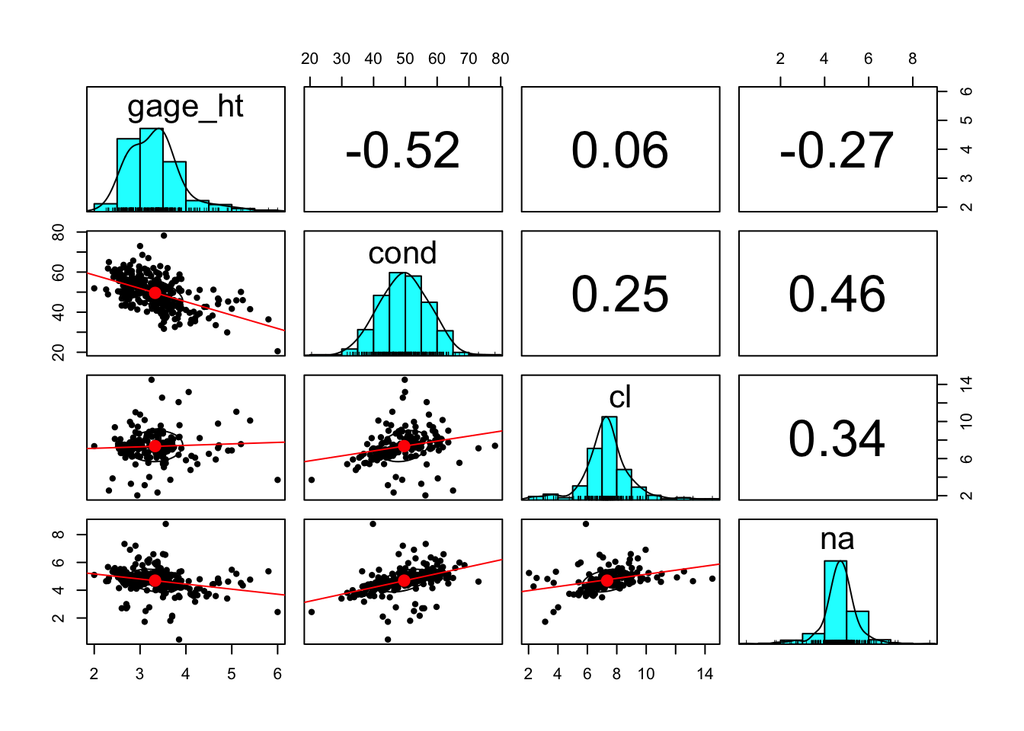

```r
## Step 1. View the structure of `luq_streamchem` & determine which columns are numeric
#str(luq_streamchem)


## Step 2. Subset `luq_streamchem` into only numeric values
### you can only have numeric values in pairs.panel() or it won't work
luq_streamchem_numeric <- luq_streamchem %>%
  dplyr::select(3:6) # when you see '::' it means you want to call a function from a specific package, so in this case we want to use select() from `dplyr` package


## Step 3. Check if your subset worked
#str(luq_streamchem_numeric)


## Step 4. Run pairs.panel plot
### play around with TRUE/FALSE arguments to see what you visually prefer

pairs.panels(luq_streamchem_numeric, # ONLY NUMERIC DATA
             density = TRUE, # adds density line to histogram (black line)
             cor = TRUE, # adds correlation coefficient, r (value in top right)
             lm = TRUE) # adds fitted linear line (red line)
```

```r
## Step 5. Comment on correlation trends (below)
```

Reminder, correlations can only be between TWO variables. For the first relationship between `gage_ht` and `cl`, based on the correlation coefficient of 0.06 and the relatively flat red line in the scatter plot, these two variables are trending not correlated. For the second relationship between `gage_ht` and `na`, based on the correlation coefficient of -0.27 and relatively negative slope of red line, I would suggest a negative correlative trend between `gage_ht` and `na` but cannot say if it’s significant without running the Pearson’s correlation test.

**2. Is the `gage_ht` (number denoting the height of water surface in meters) correlated with the stream `cond` (number denoting conductivity in micro siemens/cm)?**

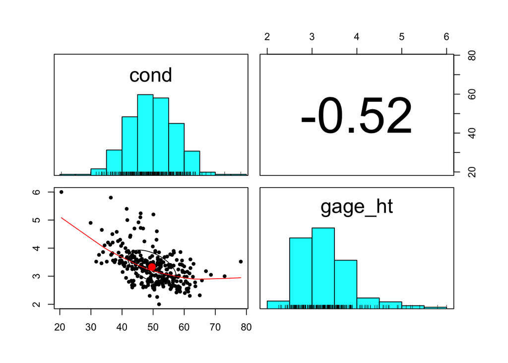

```r
## Step 1. Subset the numeric dataaset further into a dataset with just `gage_ht` and `cond`.
luq_streamchem_numeric_subset <- luq_streamchem_numeric %>%
  dplyr::select(c(cond, gage_ht))


## Step 2. Check if your subset worked
#str(luq_streamchem_numeric_subset)


## Step 3. Run pairs.panel plot
### play around with TRUE/FALSE arguments to see what you visually prefer
pairs.panels(luq_streamchem_numeric_subset,
             density = FALSE, # no density line added to histogram (black line)
             cor = TRUE, # adds correlation coefficient, r (value in top right)
             lm = FALSE) # does not add fitted linear line (red line)
```

```r
## Step 4. Based on the pairs.panels(), do you think the assumptions of the Pearson's correlation test have been met?
# Assumption 1: X & Y follow a bivariate normal distribution
# Can confirm with the following features
# a) relationship between X & Y linear? --> check, red line is somewhat straight 1:1
# b) points have an ellipital shape? --> check, some outliers but nothing too big
# c) X & Y are normal? --> check, the histograms mostly are normal, esp `cond`



## Step 5. Run a Pearson's correlation test
cor.test(luq_streamchem_numeric_subset$cond, # one numeric variable
         luq_streamchem_numeric_subset$gage_ht, # second numeric variable
         method = "pearson", # MUST specify if it's pearson or spearman
         alternative = "two.sided") # value can be above or below threshold vs one side the value is either larger or smaller
```

```
##
##  Pearson's product-moment correlation
##
## data:  luq_streamchem_numeric_subset$cond and luq_streamchem_numeric_subset$gage_ht
## t = -10.461, df = 292, p-value < 2.2e-16
## alternative hypothesis: true correlation is not equal to 0
## 95 percent confidence interval:
##  -0.6006300 -0.4336164
## sample estimates:
##        cor
## -0.5221107
```

```r
## Step 6. Comment on results (below)
```

First, look at *cor*. This is r. An **r = -0.52** suggests a strong, negative correlation between `gage_ht` and `cond`. We can use our hypothesis test to look at this. The **p-value < 2.2e-16** (ie p < 0.05), therefore we *reject $H_0$* that there is no significant correlation between water gage height (m) and water conductivity (micro siemens/cm). We can also report our test statistic t= -10.5, degree of freedom = 292, and 95% CI (-0.6 - -0.4, does not contain 0). Hence, there is a **significant and negative correlation between gage height and water conductivity.**

## Exercise 2: Correlation (non parametric, Spearman)

In this exercise, we will look at `wildlife_trade` which includes data on wildlife product imports from 2000-2014 in the US. This data is based on a subset of data from a paper by Eskew et al (Scientific Data 2020). Check out the paper for more details regarding data collection.

From the paper, “The global wildlife trade network is a massive system that has been shown to threaten biodiversity, introduce non-native species and pathogens, and cause chronic animal welfare concerns.” For this exercise, we will look at the correlation between the `value` (USD $) and `quantity` (numeric quantity) of wildlife product. Maybe we can assume that the higher the value of product, there is probably less quantity of it, increasing its value (based on economics or something like that).

We will run through the same steps as Exercise 1 but will show how to deal with data that is non-normal and non-transformable.

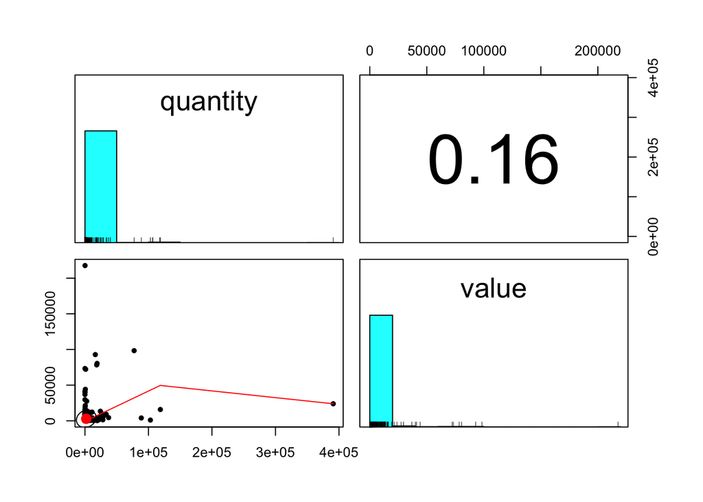

```r
## Step 1. Subset the dataset just numeric columns `quantity` and `value`.

wildlife_trade_numeric <- wildlife_trade %>%
  dplyr::select(quantity, value)


## Step 2. Check if your subset worked
#str(wildlife_trade_numeric)


## Step 3. Run pairs.panel plot
### play around with TRUE/FALSE arguments to see what you visually prefer
pairs.panels(wildlife_trade_numeric,
             density = FALSE, # no density line added to histogram (black line)
             cor = TRUE, # adds correlation coefficient, r (value in top right)
             lm = FALSE) # does not add fitted linear line (red line)
```

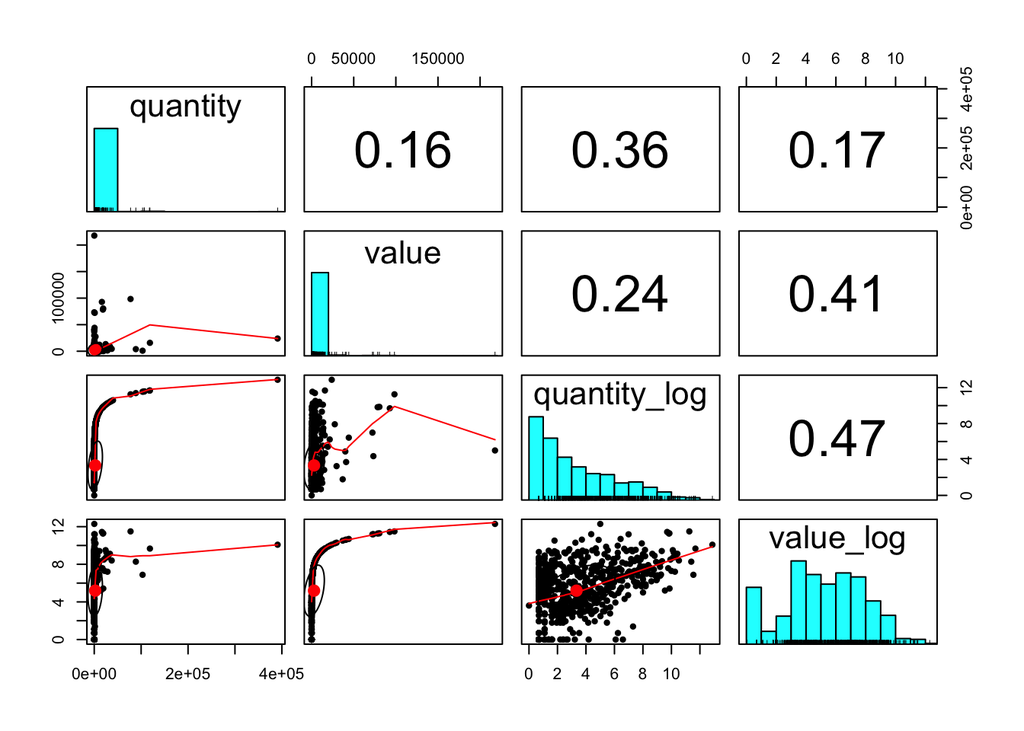

```r
## Step 4. Transform data
### Data is HIGHLY non-normal so let's do a log transformation
wildlife_trade_numeric_transformed <- wildlife_trade_numeric %>%
  mutate(quantity_log = log(quantity +1),
         value_log = log(value + 1))


## Step 5. See if transformation made variables normal (ie bell curve histograms) and check our assumptions
pairs.panels(wildlife_trade_numeric_transformed,
             density = FALSE, # no density line added to histogram (black line)
             cor = TRUE, # adds correlation coefficient, r (value in top right)
             lm = FALSE) # does not add fitted linear line (red line) # Although the data is more normal then before, it does not look like we will meet our assumption of X & Y are normally distributed so we will have to run a Spearman's rank correlation test
```

```r
## Step 6. Run a Spearman's rank correlation test
### Because we are running a non-parametric test, we don't need to use our transformed variables and can continue with the regular data since this is a rank-based test (non-parametric) and not central-tendacy test (parametric)

cor.test(wildlife_trade_numeric$value, # one numeric variable
         wildlife_trade_numeric$quantity, # second numeric variable
         method = "spearman", # MUST specify if it's pearson or spearman
         alternative = "two.sided") # value can be above or below threshold vs one side the value is either larger or smaller
```

```
##
##  Spearman's rank correlation rho
##
## data:  wildlife_trade_numeric$value and wildlife_trade_numeric$quantity
## S = 27561327, p-value < 2.2e-16
## alternative hypothesis: true rho is not equal to 0
## sample estimates:
##      rho
## 0.437675
```

```r
## Step 6. Comment on results (below)
```

First, look at $\rho$. This is the Spearman’s rank correlation coefficient and, like *r*, it varies from -1 to 1. The positive value **($\rho$ = 0.44)** tells us that there is a positive association between our variables. Next, look at the p-value for our hypothesis test **(p-value < 2.2e-16)**. Therefore we reject (p < 0.05) the $H_0$ that there is no significant correlation between the **ranks** of wildlife value and the **ranks** of wildlife quantity. Notice that because we are using a Spearman’s test we are reporting on the **ranks** and not actual value of either variable. Another difference about the Spearman’s rank correlation test is the **test statistic is S** (not t) = 27561327. From this test, we can say there is a signficant, positive correlation between the rank of wildlife value and rank of wildlife product.

## Exercise 3: Linear Regression Model

For the last exercise, we will be using the data set `deet`. According to the [EPA](https://www.epa.gov/insect-repellents/deet), “DEET (chemical name, N, N-diethyl-meta-toluamide) is the active ingredient in many repellent products. Every year, an estimated one-third of the US population use DEET to protect them from mosquito-borne illnesses like West Nile Virus or Lyme disease.”

In this example, **X** is the amount of DEET `dose` and **Y** is the number of mosquito `bites`. Unlike correlation analysis, in linear regression we are trying to predict Y from X, so we can ask :

**1. Does increasing the amount of DEET dose you use decrease the number of mosquito bites you get?**

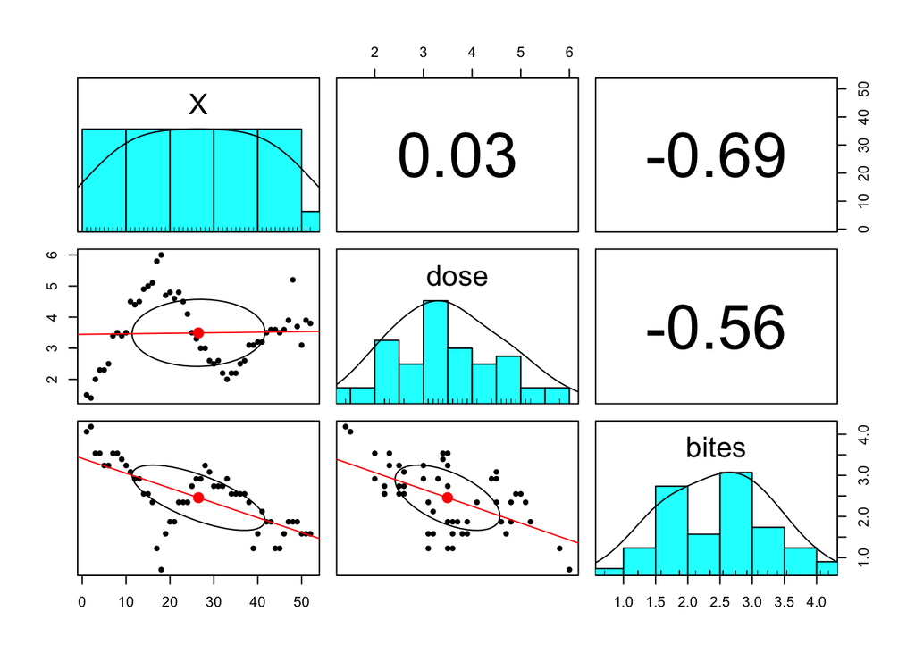

```r
## Step 1. View dataset
#str(deet)

## Step 2. Visualize data with a scatterplot
pairs.panels(deet, # must be numeric data
             density = TRUE, # add density line added to histogram (black line)
             cor = TRUE, # adds correlation coefficient, r (value in top right)
             lm = TRUE) # add fitted linear line (red)
```

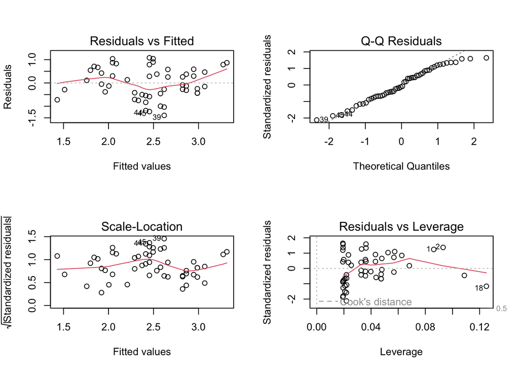

```r
## Step 3. Check assumption -- is there a linear relationship between X & Y?
# There appears to be a linear relationship between deet dose and mosquito bite number (ie relatively 1:1 linear red line)! If there was not a linear relationship we would need to try a transformation.

## Step 4. Check for assumptions -- normality & equal variance?
# Similar to ANOVA, you will have to run the test to then assess the assumptions of normality & equal variance

#Step 4a. Run linear regreesion model
deet.lm <- lm(bites ~ dose, data = deet)

# Step 4b. Check residuals vs fitted & q-q residuals plot
par(mfrow = c(2,2))
plot(deet.lm) # Just like with ANOVA, the second plot (Q-Q Residuals) tests our assumptions of normality. We can see that the QQplot of our residuals does not deviate much from the straight line so we can conclude that our assumption of normality is met. If we then look at the first plot (Residuals vs Fitted), we see that the red line is not perfectly horizontal, but there is no distinct pattern in the residuals above the 0 line. Therefore, our equal variance assumption is met. If our assumptions were not met we could try some data transformations.
```

```r
# Step 5. Interpret regression model results (below)
summary(deet.lm)
```

```
##
## Call:
## lm(formula = bites ~ dose, data = deet)
##
## Residuals:
##      Min       1Q   Median       3Q      Max
## -1.39391 -0.44256 -0.06806  0.55479  1.08079
##
## Coefficients:
##             Estimate Std. Error t value Pr(>|t|)
## (Intercept)  3.88902    0.31512  12.342  < 2e-16 ***
## dose        -0.40979    0.08624  -4.752 1.74e-05 ***
## ---
## Signif. codes:  0 '***' 0.001 '**' 0.01 '*' 0.05 '.' 0.1 ' ' 1
##
## Residual standard error: 0.6646 on 50 degrees of freedom
## Multiple R-squared:  0.3111, Adjusted R-squared:  0.2973
## F-statistic: 22.58 on 1 and 50 DF,  p-value: 1.741e-05
```

Let’s work through this output since there is a ton of information

1. Locate your estimates for $\beta_0$ & $\beta_1$ in **Coefficient** section under **Estimate** :
   - $\beta_0$ = intercept = 3.88902
   - $\beta_1$ = dose = -0.40979
   - you interpret $\beta_1$ as follows : **for every one unit increase in the dose of DEET, there is a corresponding 0.40979 decrease in the number of mosquito bites a person receives**
- to make a prediction linear model you would write: $Y_i = 3.889 - 0.409X_i$
2. Look at the column **Pr(>|t|)** for your p-values
   - Remember that $H_0$ for linear regression is that our $\beta_1 = 0$. In other words, is **dose** a significant predictor of **bites**?
   - We see that the p-value for dose is **p-value = 1.74e-05**. We can **reject our $H_0$** and say that the amount of DEET dose is a significant predictor of the number of mosquito bites (ie the slope is not 0). More specifically, as we **increase the dose of DEET, we see a significant decrease in mosquito bites**.
3. Find the $R^2$ of the linear regression model
   - $R^2$ = multiple-R-squared = 0.311
   - We interpret this value: **31.1% of the variation in the number of mosquito bites (Y) can be explained by the dose of DEET (X).**

# Additional Resources for Final Project

For your Final Project, you will be responsible for creating a professional looking report about a biological system you investigated using statistical tests and R skills you learned throughout EEMB 146. Some additional skills that would elevate your report :

- [ggcorrplot](https://rpubs.com/Alema/1000474) for *fancier* correlation visuals
- [more practice w/ interpretting lm outputs](https://feliperego.github.io/blog/2015/10/23/Interpreting-Model-Output-In-R)
- [more practice w/ interpretting diagnostic plots for lm](https://data.library.virginia.edu/diagnostic-plots/)

# Vocab

As a reminder,

- **parametric test** : use when assumptions about the distribution of the population are met
- **non-parametric test** : use when assumptions are not met, so the data can be collected from a sample that does not follow a specific distribution

### End of Exercise 7